# Topics Modelling for Earthworms Metanalyses

Sophie Donnet

2024-09-06

### Packages utiles

```r
library(dplyr)
library(ggplot2)
library(tidytext)
library(tm) # text mining
library(topicmodels) # lda estimation
library(sbm) # Poisson lbm estimation
library(knitr)
```

# A.The data

We load the dataset prepared by A. Mallet. We remove line 85 which is empty or nearly.

```r
earthworms <- read.csv(folder_nm)
earthworms[85, 1:5]
```

```
##     X  MA
## 85 85 MA4
##                                                                            Title
## 85 An experimental study of the effects of certain earthworms on crop production
##    First.author Last.author
## 85          N/A         N/A
```

```r
nrow(earthworms)
```

```
## [1] 116
```

The dataset has now 115 rows (documents) and is organized as follows:

```
## [1] "X"              "MA"             "Title"          "First.author"
## [5] "Last.author"    "Abstract"       "OnResearchgate" "DOI"
## [9] "rg_URL"
```

```
## [1] 115
```

### About the abstracts

We consider the abstracts. We remove the numbers, punctuation, we “stem” (i.e. remove plural marks etc…) and we remove the stopwords.

```r
abstracts=earthworms$Abstract
abstracts <- Corpus(VectorSource(abstracts))

TDM_abstract <- DocumentTermMatrix(abstracts,
                        control = list(removeNumbers = TRUE,
                                       removePunctuation = TRUE,
                                       stemming = TRUE,
                                       stopwords = TRUE))
```

We remove the word `earthworms` which is not informative

```r
# Step 1: Calculate term frequencies
term_freq <- colSums(as.matrix(TDM_abstract))
# Step 3: Remove these terms from the DocumentTermMatrix
TDM_abstract_filt <- TDM_abstract[, !colnames(TDM_abstract) %in% c('earthworm')]
```

We obtain a “matrix” of size 115 documents and 2239 words. We can plot the 20 most seen words

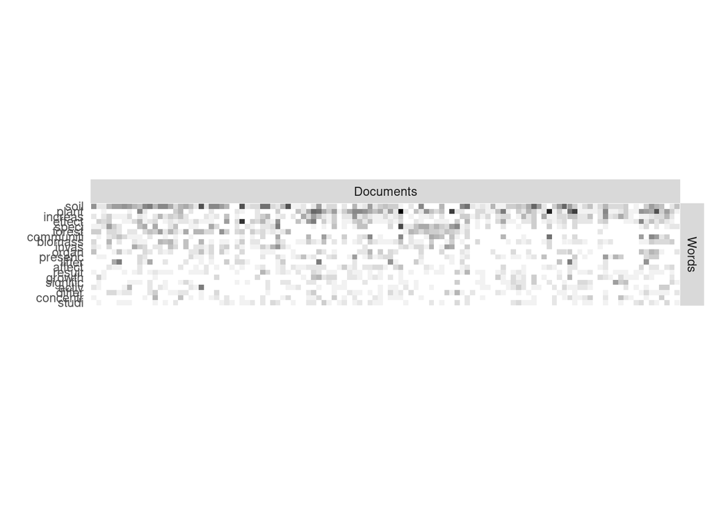

```r
TDM_abstract <- TDM_abstract_filt
M <- as.matrix(TDM_abstract)
o <- order(colSums(M), decreasing = TRUE)
Mo <- M[,o[1:20]]
library(sbm)
plotMyMatrix(t(Mo),dimLabels = c(row = "Words",col = "Documents" ),plotOptions= list(rowNames = TRUE))
```

# B. Latent Dirichlet Allocation estimation

### B.1. Pb of randomness in the estimates

For $K=4$ and $K=2$, we tru $50$ several seeds to see how the results vary from one seed to another.

```r
Nbseeds  = 50
res_LDA = vector(mode = "list", length = Nbseeds)
log_lik = rep(-Inf,Nbseeds)
ACS = rep(-Inf,Nbseeds) # average cosine similarity

K = 2
for(s in 1:50){
  print(s)
  res_lda_K_s<-  LDA(TDM_abstract, k = K, seed = s, method = "VEM",control = list())
  res_LDA[[s]] <-  res_lda_K_s
  log_lik[s] <- sum(res_lda_K_s@loglikelihood)
  Corr_K <-  cor(t(res_lda_K_s@beta))
  diag(Corr_K) <- 0
  ACS[s] <- sum(Corr_K)/(K*(K-1))
}
save(res_LDA,log_lik,ACS,file='res_LDA_severalseed_K=2.Rdata')
```

We plot all the likelihoods obtained for the various seeds.

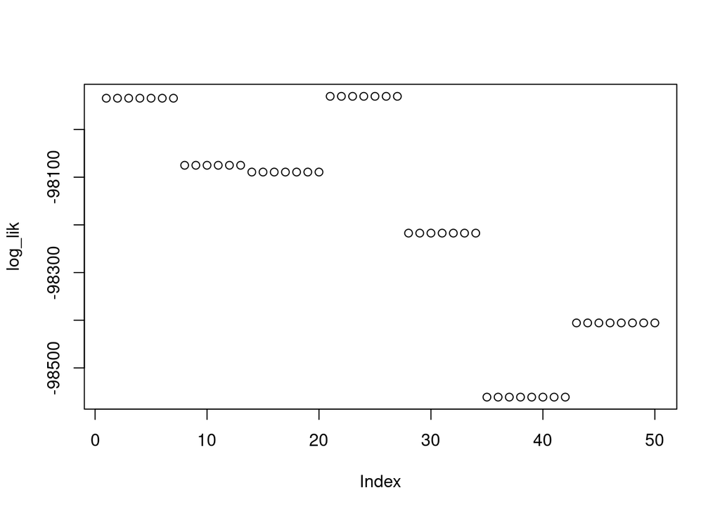

```r
load(file='res_LDA_severalseed_K=2.Rdata')
plot(log_lik)
```

```r
w  = which.max(log_lik)
lda_cluster_documents <- apply(res_LDA[[w]]@gamma,1,which.max)
knitr::kable(table(as.factor(lda_cluster_documents),earthworms$MA))
```

| MA1 | MA2 | MA3 | MA4 |
| --- | --- | --- | --- |
| 36 | 0 | 9 | 23 |
| 4 | 21 | 4 | 18 |

For K equal to 4

```r
Nbseeds  = 50
res_LDA = vector(mode = "list", length = Nbseeds)
log_lik = rep(-Inf,Nbseeds)
ACS = rep(-Inf,Nbseeds) # average cosine similarity

K = 4
for(s in 1:50){
  print(s)
  res_lda_K_s<-  LDA(TDM_abstract, k = K, seed = s, method = "VEM",control = list())
  res_LDA[[s]] <-  res_lda_K_s
  log_lik[s] <- sum(res_lda_K_s@loglikelihood)
  Corr_K <-  cor(t(res_lda_K_s@beta))
  diag(Corr_K) <- 0
  ACS[s] <- sum(Corr_K)/(K*(K-1))
}
save(res_LDA,log_lik,ACS,file='res_LDA_severalseed_K=4.Rdata')
```

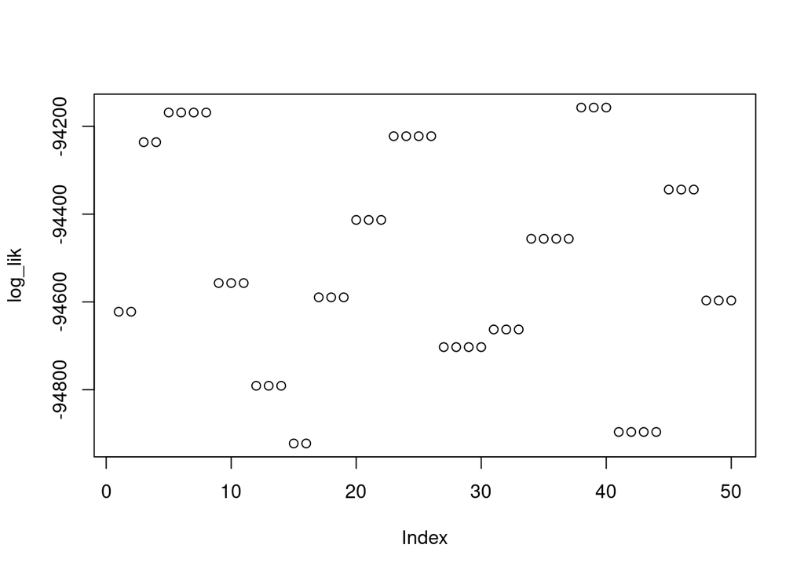

```r
load(file='res_LDA_severalseed_K=4.Rdata')
plot(log_lik)
```

```r
w  = which.max(log_lik)
lda_cluster_documents4 <- apply(res_LDA[[w]]@gamma,1,which.max)
knitr::kable(table(as.factor(lda_cluster_documents4),earthworms$MA))
```

| MA1 | MA2 | MA3 | MA4 |
| --- | --- | --- | --- |
| 3 | 6 | 0 | 16 |
| 19 | 0 | 2 | 7 |
| 3 | 14 | 0 | 16 |
| 15 | 1 | 11 | 2 |

### B.2. Inference by VEM for several values of K

```r
Kmax= 10
res_LDA = vector(mode = "list", length = Kmax-1)
log_lik = rep(-Inf,Kmax-1)
ACS = rep(-Inf,Kmax-1) # average cosine similarity
for (K in 2:Kmax){
  print(K)
  res_lda_K_current <- NULL
  log_lik_current <- -Inf
  for(s in 1:10){ # with 10 seeds.
    print(s)
    res_lda_K <-  LDA(TDM_abstract, k = K, seed = s, method = "VEM",control = list())
    if (sum(res_lda_K@loglikelihood)>log_lik_current){
      res_lda_K_current <- res_lda_K
      log_lik_current <-sum(res_lda_K@loglikelihood)
    }
  }

  res_LDA[[K-1]] <-  res_lda_K_current
  log_lik[K-1] <- sum(res_lda_K_current@loglikelihood)
  Corr_K <-  cor(t(res_lda_K@beta))
  diag(Corr_K) <- 0
  ACS[K-1] <- sum(Corr_K)/(K*(K-1))
}
save(res_LDA,log_lik,ACS,file='res_LDA.Rdata')
```

### B.3. Choice of K

It seems that the minimal ACS is obtained for $K=2$ topics. ASC is the Topic Similarity Following Cao et al. (2009), the optimal number of topics is often selected by minimizing the average cosine similarity (ACS) across topics. It its obtained by the following formulae:
$$ACS =\frac{1}{K(K-1)} \sum_{k=1,\ell\neq
k}^{K}\text{corr}(\beta_k,\beta_\ell)$$

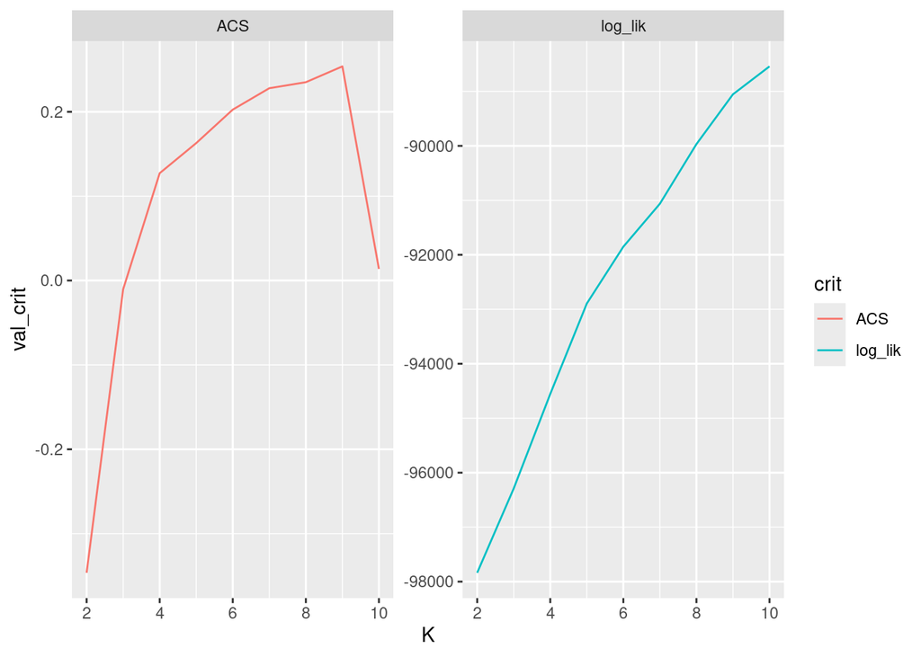

```r
load(file='res_LDA.Rdata')
Kmax <- length(log_lik)+1
res = data.frame(val_crit=c(log_lik,ACS))
res$K <- rep(2:Kmax,2)
res$crit = as.factor(rep(c('log_lik','ACS'),each=Kmax-1))
ggplot(res,aes(x=K,y=val_crit,col=crit,group=crit)) + geom_line() + facet_wrap(~crit,scales="free_y")
```

### B.4. Analysis of the results for 2 or 4 topics

We look at the words the most involved in each topic. They seem very similar. Let’s see if the documents can be clustered.

#### B.4.1. Analysis with 2 topics

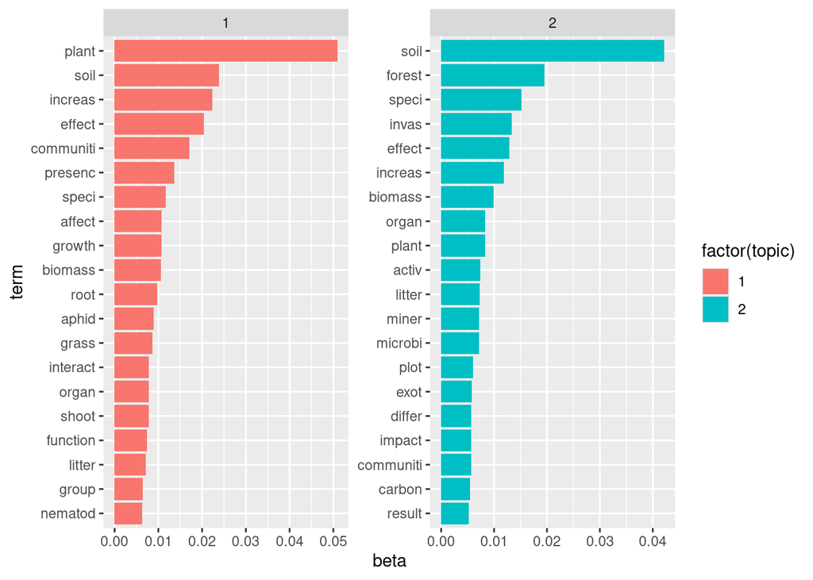

```r
K = 2
abstract_topics <- tidy(res_LDA[[K-1]], matrix = "beta")
abstract_top_terms <- abstract_topics %>%
  group_by(topic) %>%
  slice_max(beta, n = 20) %>%
  ungroup() %>%
  arrange(topic, -beta)
abstract_top_terms %>%
  mutate(term = reorder_within(term, beta, topic)) %>%
  ggplot(aes(beta, term, fill = factor(topic))) +
  geom_col() +
  facet_wrap(~ topic, scales = "free") +
  scale_y_reordered()
```

```r
K = 2
lda_cluster_documents2 <- apply(res_LDA[[K-1]]@gamma,1,which.max)
knitr::kable(table(as.factor(lda_cluster_documents2),earthworms$MA))
```

| MA1 | MA2 | MA3 | MA4 |
| --- | --- | --- | --- |
| 4 | 21 | 1 | 21 |
| 36 | 0 | 12 | 20 |

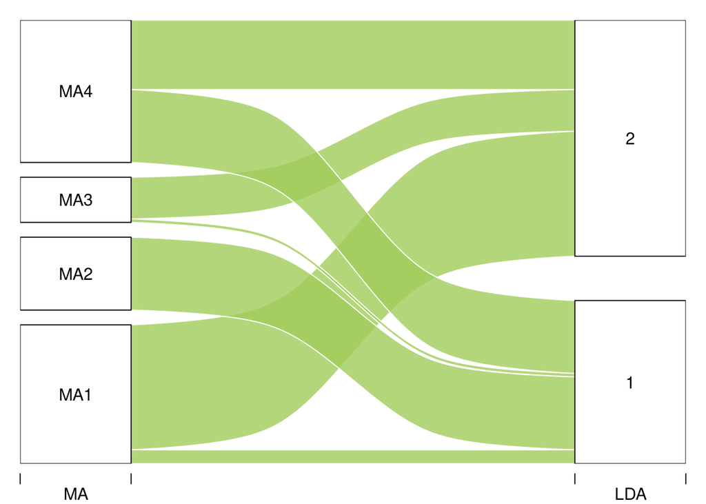

```
## $plotOptions
## $plotOptions$curvy
## [1] 0.3
##
## $plotOptions$alpha
## [1] 0.8
##
## $plotOptions$gap.width
## [1] 0.1
##
## $plotOptions$col
## [1] "darkolivegreen3"
##
## $plotOptions$border
## [1] "white"
##
##
## $tableFreq
##    MA LDA Freq
## 1 MA1   1    4
## 2 MA2   1   21
## 3 MA3   1    1
## 4 MA4   1   21
## 5 MA1   2   36
## 7 MA3   2   12
## 8 MA4   2   20
```

```r
plotAlluvial(list(MA =earthworms$MA, LDA = lda_cluster_documents2))
```

#### B.4.2. Analysis with 4 topics

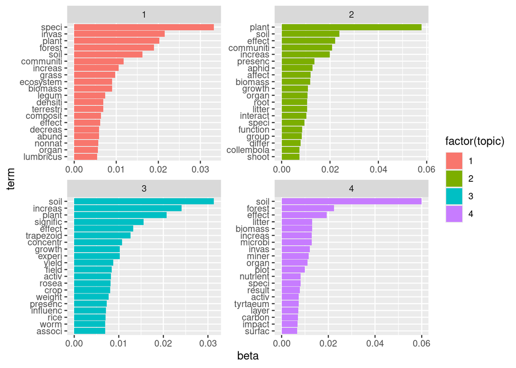

```r
K = 4
abstract_topics <- tidy(res_LDA[[K-1]], matrix = "beta")
abstract_top_terms <- abstract_topics %>%
  group_by(topic) %>%
  slice_max(beta, n = 20) %>%
  ungroup() %>%
  arrange(topic, -beta)
abstract_top_terms %>%
  mutate(term = reorder_within(term, beta, topic)) %>%
  ggplot(aes(beta, term, fill = factor(topic))) +
  geom_col() +
  facet_wrap(~ topic, scales = "free") +
  scale_y_reordered()
```

```r
K = 4
lda_cluster_documents4 <- apply(res_LDA[[K-1]]@gamma,1,which.max)
knitr::kable(table(as.factor(lda_cluster_documents4),earthworms$MA))
```

| MA1 | MA2 | MA3 | MA4 |
| --- | --- | --- | --- |
| 13 | 3 | 10 | 7 |
| 4 | 15 | 2 | 10 |
| 2 | 3 | 0 | 19 |
| 21 | 0 | 1 | 5 |

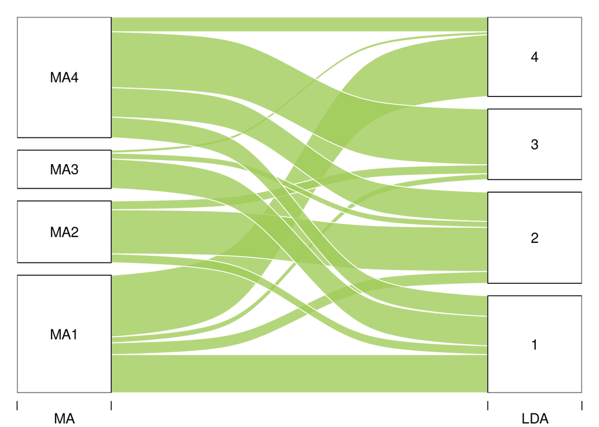

```
## $plotOptions
## $plotOptions$curvy
## [1] 0.3
##
## $plotOptions$alpha
## [1] 0.8
##
## $plotOptions$gap.width
## [1] 0.1
##
## $plotOptions$col
## [1] "darkolivegreen3"
##
## $plotOptions$border
## [1] "white"
##
##
## $tableFreq
##     MA LDA Freq
## 1  MA1   1   13
## 2  MA2   1    3
## 3  MA3   1   10
## 4  MA4   1    7
## 5  MA1   2    4
## 6  MA2   2   15
## 7  MA3   2    2
## 8  MA4   2   10
## 9  MA1   3    2
## 10 MA2   3    3
## 12 MA4   3   19
## 13 MA1   4   21
## 15 MA3   4    1
## 16 MA4   4    5
```

```r
plotAlluvial(list(MA =earthworms$MA, LDA = lda_cluster_documents4))
```

# C. Latent block model estimation

```r
colsumsM <- colSums(M)
plot(ecdf(colsumsM), main="Repartition function of the frequencies of words")

w2 <- which(colsumsM<=2) # words seen only one time across ALL the abstracts
wmax <- order(colsumsM,decreasing=TRUE)[1:3]
Mshort <- M[,-c(w2,wmax)]

o <- order(colSums(M), decreasing = TRUE)

res_lbm <- estimateBipartiteSBM(Mshort,model="poisson",dimLabels=c(row="Documents", col="Words"), estimOptions = list(nbCores = 6))#exploreMax = 10))
 save(res_lbm,file='res_lbm.Rdata')
```

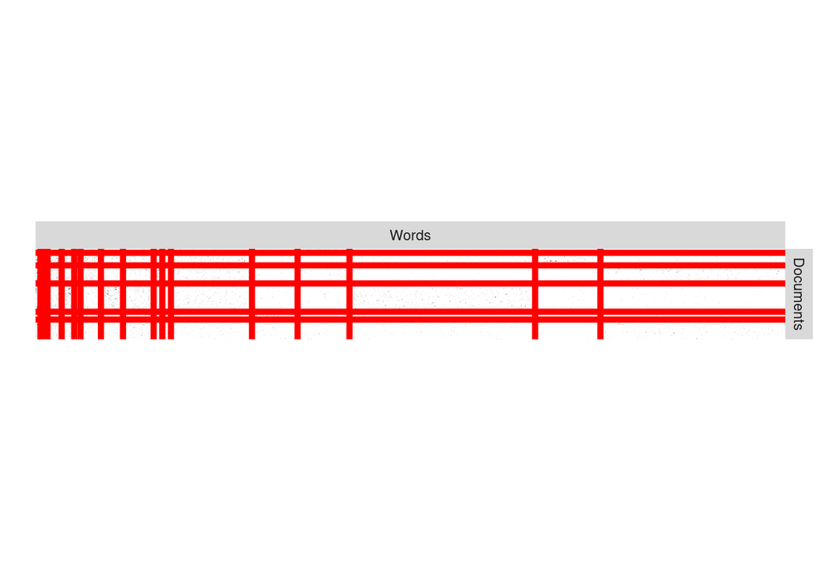

```r
load("res_lbm.Rdata")
plot(res_lbm)
```

```r
knitr::kable(table(as.factor(res_lbm$memberships$Documents),earthworms$MA))
```

| MA1 | MA2 | MA3 | MA4 |
| --- | --- | --- | --- |
| 0 | 3 | 0 | 2 |
| 9 | 1 | 2 | 4 |
| 1 | 13 | 0 | 9 |
| 24 | 0 | 11 | 1 |
| 2 | 0 | 0 | 8 |
| 4 | 4 | 0 | 17 |

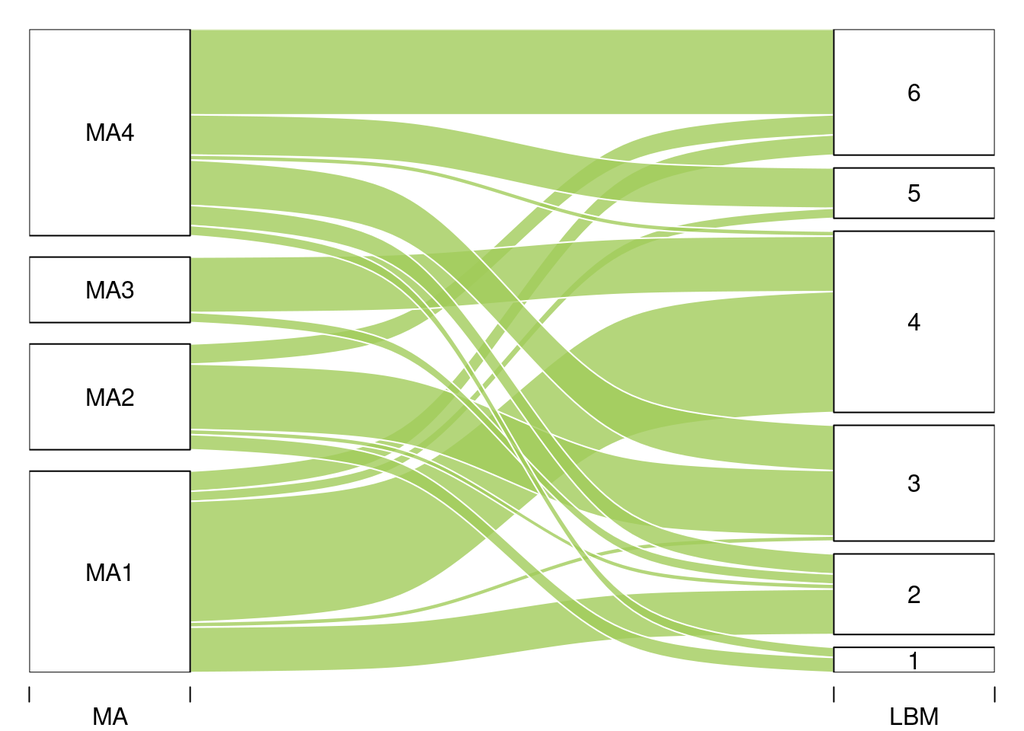

```
## $plotOptions
## $plotOptions$curvy
## [1] 0.3
##
## $plotOptions$alpha
## [1] 0.8
##
## $plotOptions$gap.width
## [1] 0.1
##
## $plotOptions$col
## [1] "darkolivegreen3"
##
## $plotOptions$border
## [1] "white"
##
##
## $tableFreq
##     MA LBM Freq
## 2  MA2   1    3
## 4  MA4   1    2
## 5  MA1   2    9
## 6  MA2   2    1
## 7  MA3   2    2
## 8  MA4   2    4
## 9  MA1   3    1
## 10 MA2   3   13
## 12 MA4   3    9
## 13 MA1   4   24
## 15 MA3   4   11
## 16 MA4   4    1
## 17 MA1   5    2
## 20 MA4   5    8
## 21 MA1   6    4
## 22 MA2   6    4
## 24 MA4   6   17
```

```r
plotAlluvial(list(MA =earthworms$MA, LBM = res_lbm$memberships$Documents))
```